# Part-2 Coding Exam

## Outlines

- Creating Arrays
- Initial Placeholders
- Array Inspection
- Array Mathematics
- Array Manipulation
- DataFrame
- Selecting, Boolean Indexing & Setting
- Dropping
- Retrieving DataFrame Information

## Notes

- All problems MUST be solved
- Read the problems well, before you start solving.
- The solution MUST pass all the test cases
- Feel free to add more cells to develope the program, BUT make sure you gather them in ONE adequately working code cell.
- You also should create all the numpy input arrays first.

### This exam consists of 34 mini-questions based on what you toke in session and also on some simple research you should make online.

# Pandas and Numpy

## Problem 1

#### Write a NumPy program to test whether each element of a 1-D array is also present in a second array.

#### Expected Output:

#### Array1: [ 0 10 20 40 60]

#### Array2: [0, 40]

#### Compare each element of array1 and array2

#### Output: [ True False False True False]

```python
### Write Your Code Here
import numpy as np

class Solution:
    def get_intersect(self, arr1, arr2):
        print("The output is: ")
        return np.in1d(arr1, arr2)

#Deifining the arrays:

arr1 = np.array([0, 10, 20, 40, 60])
arr2 = np.array([0, 40])

#Call the Function
Solution().get_intersect(arr1, arr2)
```

```
The output is:
```

```
array([ True, False, False,  True, False])
```

## Problem 2

#### Write a NumPy program to get the unique elements of an array

#### Expected Output:

#### Original array:

#### [10 10 20 20 30 30]

#### Unique elements of the above array:

#### [10 20 30]

#### Original array:

#### [[1 1]

#### [2 3]]

#### Unique elements of the above array:

#### [1 2 3]

```python
### Write Your Code Here ###
import numpy as np

class Solution:
    def get_unique(self, arr):
        print("The output is:")
        return np.unique(arr)



arr1 = np.array([10, 20, 20, 30, 30])
arr2=np.array([[1,1], [2,3]])
Solution().get_unique(arr2)
```

```
The output is:
```

```
array([1, 2, 3])
```

## Problem 3

#### Write a NumPy program to sort an along the first, last axis of an array.

#### Sample array: [[2,5],[4,4]]

#### Expected Output:

#### Original array:

#### [[4 6]

#### [2 1]]

#### Sort along the first axis:

#### [[2 1]

#### [4 6]]

#### Sort along the last axis:

#### [[1 2]

#### [4 6]]

```python
### Write Your Code Here ###
import numpy as np

class Solution:
    def sort_f_axis (self, arr):
        print("the output sort by first axis is")
        return np.sort(arr,axis=0)

    def sort_l_axis(self, arr):
        print("the output sort by last axis is")
        return np.sort(np.sort(arr, axis=0), axis=1)

arr=np.array([[4,6], [2,1]])

print(Solution().sort_f_axis(arr))
print(Solution().sort_l_axis(arr))
```

```
the output sort by first axis is
[[2 1]
 [4 6]]
the output sort by last axis is
[[1 2]
 [4 6]]
```

## Problem 4

#### Write a NumPy program to count the occurrence of a specified item in a given NumPy array.

#### Sample Output:

#### Original array:

#### [10 20 20 20 20 0 20 30 30 30 0 0 20 20 0]

#### [4,1,7,3]

```python
### Write Your Code Here ###
import numpy as np

class Solution:
    def get_occurrences(self, arr):
        arr_unique = np.unique(arr)
        lst = []

        for i in arr_unique:
            lst.append(np.count_nonzero(arr==i))

        print("The output is:")
        return lst

arr=np.array([10, 20, 20, 20, 20, 0, 20, 30, 30, 30, 0, 0 , 20, 20, 0])
Solution().get_occurrences(arr)
```

```
The output is:
```

```
[4, 1, 7, 3]
```

## Problem 5

#### Write a NumPy program to remove nan values from a given array.

#### Sample Output:

#### Original array:

#### [200. 300. nan nan nan 700.]

#### After removing nan values:

#### [200. 300. 700.]

```python
### Write Your Code Here ###
import numpy as np
class Solution:
    def get_occurrences(self,arr):
        new_arr = np.nan_to_num(arr)
        new_arr = new_arr[new_arr != 0]

        print("The output is:")

        return new_arr

arr = np.array([200, 300, np.nan, np.nan, np.nan, 700])

Solution().get_occurrences(arr)
```

```
The output is:
```

```
array([200., 300., 700.])
```

## Problem 6

#### Write a NumPy program to calculate percentiles for a sequence or single-dimensional NumPy array.

#### Sample Output:

#### 50th percentile (median):

#### 3.0

#### 40th percentile:

#### 2.6

#### 90th percentile:

#### 4.6

```python
### Write Your Code Here ###
class Solution:
    def get_percentile(self, arr, percent):
        if percent=="median":
            percent = 50

        print(f"the {percent}th of array is: ")

        return np.percentile(arr, percent)

arr = np.array([1, 2, 3, 4, 5, 7, 8])

print(Solution().get_percentile(arr, "median"))

print(Solution().get_percentile(arr, 10))
```

```
the 50th of array is:
4.0
the 10th of array is:
1.6
```

## Problem 7

#### Write a NumPy program to find indices of elements equal to zero in a NumPy array.

#### Sample Output:

#### Original array:

#### [1 0 2 0 3 0 4 5 6 7 8]

#### Indices of elements equal to zero of the said array:

#### [1 3 5]

```python
### Write Your Program Here ###
import numpy as np
class Solution:
    def get_indices(self, arr):
        arr = np.where(arr==0)[0]

        print("The Ouptut is: ")

        return arr


arr = np.array([1, 0, 2, 0, 3, 0, 4, 5, 6, 7, 8])
Solution().get_indices(arr)
```

```
The Ouptut is:
```

```
array([1, 3, 5], dtype=int64)
```

## Problem 8

#### Write a NumPy program to round elements of the array to the nearest integer, and then calculate the abslute value element wise.

#### Sample Output:

#### Original array:

#### [-0.7 -1.5 -1.7 0.3 1.5 1.8 2. ]

#### Round elements of the array to the nearest integer:

#### [1. 2. 2. 0. 2. 2. 2.]

```python
### Write Your Program Here ###
import numpy as np

class Solution:
    def get_indices(self, arr):

        print("The outpout is:")

        return np.abs(np.rint(arr))

arr = np.array([-0.7, -1.5, -1.7, 0.3, 1.5, 1.8, 2.])
Solution().get_indices(arr)
```

```
The outpout is:
```

```
array([1., 2., 2., 0., 2., 2., 2.])
```

## Problem 9

#### Write a NumPy program to calculate the difference between neighboring elements, element-wise, and prepend [0, 0] and append[200] to a given array.

#### Sample output:

#### Original array:

#### [1 3 5 7 0]

#### Difference between neighboring elements, element-wise, and prepend [0, 0] and append[200] to the said array:

#### [ 0 0 2 2 2 -7 200]

#### Note: difference between neighboring elements means: $out[i] = a[i+1] - a[i]$

```python
### Write Your Code Here ###
import numpy as np

class Solution:
    def get_arr(self, arr):
        arr2 = np.diff(arr)
        arr2 = np.insert(arr2, 0, [0,0])
        arr2 = np.append(arr2, 200)

        print("The outpout is: ")

        return arr2

arr = np.array([1, 3, 5, 7, 0])
Solution().get_arr(arr)
```

```
The outpout is:
```

```
array([  0,   0,   2,   2,   2,  -7, 200])
```

## Problem 10

#### Write a NumPy program to get the indices of the sorted elements of a given array.

#### Expected Output:

#### Original array:

#### [1023 5202 6230 1671 1682 5241 4532]

#### Indices of the sorted elements of a given array:

#### [0 3 4 6 1 5 2]

```python
### Write Your Code Here ###
import numpy as np
class Solution:
    def get_indices(self, arr):
        sorted_arr = np.sort(arr)
        lst=[]

        for i in range(arr.shape[0]):
            lst.append(np.where(arr==sorted_arr[i])[0][0])

        arr = np.array(lst)

        print("The ouput is:")

        return arr


arr = np.array([1023, 5202, 6230, 1671, 1682, 5241, 4532])
Solution().get_indices(arr)
```

```
The ouput is:
```

```
array([0, 3, 4, 6, 1, 5, 2], dtype=int64)
```

## Problem 11

#### Write a NumPy program to partition a given array in a specified position and move all the smaller elements values to the left of the partition, and the remaining values to the right, in arbitrary order (based on random choice).

#### Sample output:

#### Original array:

#### [ 70 50 20 30 -11 60 50 40]

#### After partitioning on 4 the position:

#### [-11 30 20 40 50 50 60 70]

```python
### Write Your Code Here ###
import numpy as np

class Solution:
    def make_partioning(self, arr, position):

        print("The Output is")

        return np.partition(arr, position)

arr = np.array([70, 50, 20, 30, -11, 60, 50, 40])
Solution().make_partioning(arr, 4)
```

```
The Output is
```

```
array([-11,  30,  20,  40,  50,  50,  60,  70])
```

## Problem 12

#### Compute the euclidean distance between two arrays a and b.

#### Input:

#### [1,2,3,4,5]

#### [4,5,6,7,8]

#### Euclidean distance is: 6.7082

```python
### Write You Program Here ###
import numpy as np
class Solution:
    def get_ecludin_d(self, arr1, arr2):
        print("The Output is:")
        return np.round(np.sqrt(np.sum((arr2 - arr1)**2)), 4)


arr1 = np.array([1, 2, 3, 4, 5])
arr2 = np.array([4, 5, 6, 7, 8])

Solution().get_Ecludin_D(arr1, arr2)
```

[output not shown]

[output not shown]

## Problem 13

#### Find all the peaks in a 1D numpy array a. Peaks are points surrounded by smaller values on both sides.

#### Input:

#### array([1, 3, 7, 1, 2, 6, 0, 1])

#### Desired Output:

#### array( [2, 5])

#### where, 2 and 5 are the positions of peak values 7 and 6.

```python
### Write You Program Here ###
import numpy as np
class Solution:

    def get_peaks(self, arr):
        diff_arr = np.diff(np.sign(np.diff(arr)))
        peaks = np.where(diff_arr==-2)[0] + 1

        print("The Output is:")

        return peaks

arr = np.array([1, 3, 7, 1, 2, 8, 6, 0, 1, 9, 1, 1, 1])

Solution().get_peaks(arr)
```

```
The Output is:
```

```
array([2, 5, 9], dtype=int64)
```

## Problem 14

#### Find the index of nth repetition of number i .

#### array([1, 2, 1, 1, 3, 4, 3, 1, 1, 2, 1, 1, 2])

#### n = 5 (from user)

#### i = 1 (from user)

#### 8

```python
### Write Your Code Here ###
import numpy as np

class Solution:

    def get_index_rep(self, arr, i, n):
        arr = np.array([1, 2, 1, 1, 3, 4, 3, 1, 1, 2, 1, 1, 2])
        ind = np.where(arr==i)[0][n-1]

        print("The Output is:")

        return ind

arr = np.array([1, 2, 1, 1, 3, 4, 3, 1, 1, 2, 1, 1, 2])
Solution().get_index_rep(arr, i=1, n=5)
```

```
The Output is:
```

```
8
```

## Problem 15

### In order to solve this set of questions you will use the dataset in the relative directory ./Datasets/tmdb_5000_movies.csv

```python
### Open Your CSV file and print the first 10 rows in a good format ###
import pandas as pd

DATA_PATH = "E:\\Tahaluf Al Emarat_Task\\Admission Exam\\Datasets\\tmdb_5000_movies.csv"
df = pd.read_csv(DATA_PATH)

df.head(10)
```

|  | budget | genres | homepage | id | keywords | original_language | original_title | overview | popularity | production_companies | production_countries | release_date | revenue | runtime | spoken_languages | status | tagline | title | vote_average | vote_count |
| --- | --- | --- | --- | --- | --- | --- | --- | --- | --- | --- | --- | --- | --- | --- | --- | --- | --- | --- | --- | --- |
| 0 | 237000000 | [{"id": 28, "name": "Action"}, {"id": 12, "nam... | http://www.avatarmovie.com/ | 19995 | [{"id": 1463, "name": "culture clash"}, {"id":... | en | Avatar | In the 22nd century, a paraplegic Marine is di... | 150.437577 | [{"name": "Ingenious Film Partners", "id": 289... | [{"iso_3166_1": "US", "name": "United States o... | 2009-12-10 | 2787965087 | 162.0 | [{"iso_639_1": "en", "name": "English"}, {"iso... | Released | Enter the World of Pandora. | Avatar | 7.2 | 11800 |
| 1 | 300000000 | [{"id": 12, "name": "Adventure"}, {"id": 14, "... | http://disney.go.com/disneypictures/pirates/ | 285 | [{"id": 270, "name": "ocean"}, {"id": 726, "na... | en | Pirates of the Caribbean: At World's End | Captain Barbossa, long believed to be dead, ha... | 139.082615 | [{"name": "Walt Disney Pictures", "id": 2}, {"... | [{"iso_3166_1": "US", "name": "United States o... | 2007-05-19 | 961000000 | 169.0 | [{"iso_639_1": "en", "name": "English"}] | Released | At the end of the world, the adventure begins. | Pirates of the Caribbean: At World's End | 6.9 | 4500 |
| 2 | 245000000 | [{"id": 28, "name": "Action"}, {"id": 12, "nam... | http://www.sonypictures.com/movies/spectre/ | 206647 | [{"id": 470, "name": "spy"}, {"id": 818, "name... | en | Spectre | A cryptic message from Bond’s past sends him o... | 107.376788 | [{"name": "Columbia Pictures", "id": 5}, {"nam... | [{"iso_3166_1": "GB", "name": "United Kingdom"... | 2015-10-26 | 880674609 | 148.0 | [{"iso_639_1": "fr", "name": "Fran\u00e7ais"},... | Released | A Plan No One Escapes | Spectre | 6.3 | 4466 |
| 3 | 250000000 | [{"id": 28, "name": "Action"}, {"id": 80, "nam... | http://www.thedarkknightrises.com/ | 49026 | [{"id": 849, "name": "dc comics"}, {"id": 853,... | en | The Dark Knight Rises | Following the death of District Attorney Harve... | 112.312950 | [{"name": "Legendary Pictures", "id": 923}, {"... | [{"iso_3166_1": "US", "name": "United States o... | 2012-07-16 | 1084939099 | 165.0 | [{"iso_639_1": "en", "name": "English"}] | Released | The Legend Ends | The Dark Knight Rises | 7.6 | 9106 |
| 4 | 260000000 | [{"id": 28, "name": "Action"}, {"id": 12, "nam... | http://movies.disney.com/john-carter | 49529 | [{"id": 818, "name": "based on novel"}, {"id":... | en | John Carter | John Carter is a war-weary, former military ca... | 43.926995 | [{"name": "Walt Disney Pictures", "id": 2}] | [{"iso_3166_1": "US", "name": "United States o... | 2012-03-07 | 284139100 | 132.0 | [{"iso_639_1": "en", "name": "English"}] | Released | Lost in our world, found in another. | John Carter | 6.1 | 2124 |
| 5 | 258000000 | [{"id": 14, "name": "Fantasy"}, {"id": 28, "na... | http://www.sonypictures.com/movies/spider-man3/ | 559 | [{"id": 851, "name": "dual identity"}, {"id": ... | en | Spider-Man 3 | The seemingly invincible Spider-Man goes up ag... | 115.699814 | [{"name": "Columbia Pictures", "id": 5}, {"nam... | [{"iso_3166_1": "US", "name": "United States o... | 2007-05-01 | 890871626 | 139.0 | [{"iso_639_1": "en", "name": "English"}, {"iso... | Released | The battle within. | Spider-Man 3 | 5.9 | 3576 |
| 6 | 260000000 | [{"id": 16, "name": "Animation"}, {"id": 10751... | http://disney.go.com/disneypictures/tangled/ | 38757 | [{"id": 1562, "name": "hostage"}, {"id": 2343,... | en | Tangled | When the kingdom's most wanted-and most charmi... | 48.681969 | [{"name": "Walt Disney Pictures", "id": 2}, {"... | [{"iso_3166_1": "US", "name": "United States o... | 2010-11-24 | 591794936 | 100.0 | [{"iso_639_1": "en", "name": "English"}] | Released | They're taking adventure to new lengths. | Tangled | 7.4 | 3330 |
| 7 | 280000000 | [{"id": 28, "name": "Action"}, {"id": 12, "nam... | http://marvel.com/movies/movie/193/avengers_ag... | 99861 | [{"id": 8828, "name": "marvel comic"}, {"id": ... | en | Avengers: Age of Ultron | When Tony Stark tries to jumpstart a dormant p... | 134.279229 | [{"name": "Marvel Studios", "id": 420}, {"name... | [{"iso_3166_1": "US", "name": "United States o... | 2015-04-22 | 1405403694 | 141.0 | [{"iso_639_1": "en", "name": "English"}] | Released | A New Age Has Come. | Avengers: Age of Ultron | 7.3 | 6767 |
| 8 | 250000000 | [{"id": 12, "name": "Adventure"}, {"id": 14, "... | http://harrypotter.warnerbros.com/harrypottera... | 767 | [{"id": 616, "name": "witch"}, {"id": 2343, "n... | en | Harry Potter and the Half-Blood Prince | As Harry begins his sixth year at Hogwarts, he... | 98.885637 | [{"name": "Warner Bros.", "id": 6194}, {"name"... | [{"iso_3166_1": "GB", "name": "United Kingdom"... | 2009-07-07 | 933959197 | 153.0 | [{"iso_639_1": "en", "name": "English"}] | Released | Dark Secrets Revealed | Harry Potter and the Half-Blood Prince | 7.4 | 5293 |
| 9 | 250000000 | [{"id": 28, "name": "Action"}, {"id": 12, "nam... | http://www.batmanvsupermandawnofjustice.com/ | 209112 | [{"id": 849, "name": "dc comics"}, {"id": 7002... | en | Batman v Superman: Dawn of Justice | Fearing the actions of a god-like Super Hero l... | 155.790452 | [{"name": "DC Comics", "id": 429}, {"name": "A... | [{"iso_3166_1": "US", "name": "United States o... | 2016-03-23 | 873260194 | 151.0 | [{"iso_639_1": "en", "name": "English"}] | Released | Justice or revenge | Batman v Superman: Dawn of Justice | 5.7 | 7004 |

## NULLS

```python
### Check if any NANs in your dataset and fill them with a good filer ###
df.isna().sum()
```

```
budget                     0
genres                     0
homepage                3091
id                         0
keywords                   0
original_language          0
original_title             0
overview                   3
popularity                 0
production_companies       0
production_countries       0
release_date               1
revenue                    0
runtime                    2
spoken_languages           0
status                     0
tagline                  844
title                      0
vote_average               0
vote_count                 0
dtype: int64
```

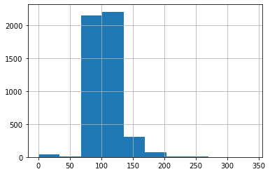

```python
import matplotlib.pyplot as plt
df["runtime"].hist()
```

```python
df["runtime"] = df["runtime"].fillna(df["runtime"].median())
```

```python
df.isnull().sum()
```

```
budget                     0
genres                     0
homepage                3091
id                         0
keywords                   0
original_language          0
original_title             0
overview                   3
popularity                 0
production_companies       0
production_countries       0
release_date               1
revenue                    0
runtime                    0
spoken_languages           0
status                     0
tagline                  844
title                      0
vote_average               0
vote_count                 0
dtype: int64
```

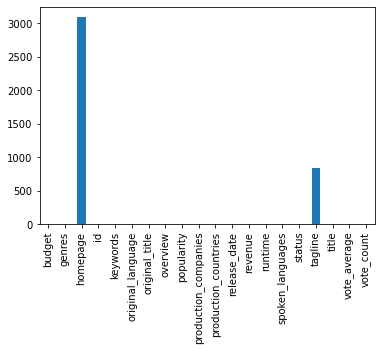

```python
df.isnull().sum().plot(kind='bar')
```

### Columns Types

```python
### Discover the types of each columns and modify them if needed ###
df.info()
```

```
<class 'pandas.core.frame.DataFrame'>
RangeIndex: 4803 entries, 0 to 4802
Data columns (total 20 columns):
 #   Column                Non-Null Count  Dtype
---  ------                --------------  -----
 0   budget                4803 non-null   int64
 1   genres                4803 non-null   object
 2   homepage              1712 non-null   object
 3   id                    4803 non-null   int64
 4   keywords              4803 non-null   object
 5   original_language     4803 non-null   object
 6   original_title        4803 non-null   object
 7   overview              4800 non-null   object
 8   popularity            4803 non-null   float64
 9   production_companies  4803 non-null   object
 10  production_countries  4803 non-null   object
 11  release_date          4802 non-null   object
 12  revenue               4803 non-null   int64
 13  runtime               4803 non-null   float64
 14  spoken_languages      4803 non-null   object
 15  status                4803 non-null   object
 16  tagline               3959 non-null   object
 17  title                 4803 non-null   object
 18  vote_average          4803 non-null   float64
 19  vote_count            4803 non-null   int64
dtypes: float64(3), int64(4), object(13)
memory usage: 750.6+ KB
```

```python
df.iloc[0:1:]
```

|  | budget | genres | homepage | id | keywords | original_language | original_title | overview | popularity | production_companies | production_countries | release_date | revenue | runtime | spoken_languages | status | tagline | title | vote_average | vote_count |
| --- | --- | --- | --- | --- | --- | --- | --- | --- | --- | --- | --- | --- | --- | --- | --- | --- | --- | --- | --- | --- |
| 0 | 237000000 | [{"id": 28, "name": "Action"}, {"id": 12, "nam... | http://www.avatarmovie.com/ | 19995 | [{"id": 1463, "name": "culture clash"}, {"id":... | en | Avatar | In the 22nd century, a paraplegic Marine is di... | 150.437577 | [{"name": "Ingenious Film Partners", "id": 289... | [{"iso_3166_1": "US", "name": "United States o... | 2009-12-10 | 2787965087 | 162.0 | [{"iso_639_1": "en", "name": "English"}, {"iso... | Released | Enter the World of Pandora. | Avatar | 7.2 | 11800 |

```python
import json

for i,row in df.iterrows():
    df.at[i,"genres"] = json.loads(df["genres"][i])

df["homepage"] = df["homepage"].astype("string")

for i,row in df.iterrows():
    df.at[i,"keywords"] = json.loads(df["keywords"][i])

df["original_language"] = df["original_language"].astype("category")
df["original_title"] = df["original_title"].astype("string")
df["overview"] = df["overview"].astype("string")

for i,row in df.iterrows():
    df.at[i,"production_companies"] = json.loads(df["production_companies"][i])

for i,row in df.iterrows():
    df.at[i,"production_countries"] = json.loads(df["production_countries"][i])

df["release_date"] = pd.to_datetime(df["release_date"])
for i,row in df.iterrows():
    df.at[i,"spoken_languages"] = json.loads(df["spoken_languages"][i])

df["status"] = df["status"].astype("category")
df["title"] = df["title"].astype("string")
df["tagline"] = df["tagline"].astype("string")
```

```python
df.info()
```

```
<class 'pandas.core.frame.DataFrame'>
RangeIndex: 4803 entries, 0 to 4802
Data columns (total 20 columns):
 #   Column                Non-Null Count  Dtype
---  ------                --------------  -----
 0   budget                4803 non-null   int64
 1   genres                4803 non-null   object
 2   homepage              1712 non-null   string
 3   id                    4803 non-null   int64
 4   keywords              4803 non-null   object
 5   original_language     4803 non-null   category
 6   original_title        4803 non-null   string
 7   overview              4800 non-null   string
 8   popularity            4803 non-null   float64
 9   production_companies  4803 non-null   object
 10  production_countries  4803 non-null   object
 11  release_date          4802 non-null   datetime64[ns]
 12  revenue               4803 non-null   int64
 13  runtime               4803 non-null   float64
 14  spoken_languages      4803 non-null   object
 15  status                4803 non-null   category
 16  tagline               3959 non-null   string
 17  title                 4803 non-null   string
 18  vote_average          4803 non-null   float64
 19  vote_count            4803 non-null   int64
dtypes: category(2), datetime64[ns](1), float64(3), int64(4), object(5), string(5)
memory usage: 686.4+ KB
```

```python
### Give a very simple statistical analsys for the numerical columns ###
df[["budget", "homepage", "popularity", "popularity", "revenue",\
    "runtime", "vote_average", "vote_count"]].describe()
```

|  | budget | popularity | popularity | revenue | runtime | vote_average | vote_count |
| --- | --- | --- | --- | --- | --- | --- | --- |
| count | 4.803000e+03 | 4803.000000 | 4803.000000 | 4.803000e+03 | 4803.000000 | 4803.000000 | 4803.000000 |
| mean | 2.904504e+07 | 21.492301 | 21.492301 | 8.226064e+07 | 106.874245 | 6.092172 | 690.217989 |
| std | 4.072239e+07 | 31.816650 | 31.816650 | 1.628571e+08 | 22.607364 | 1.194612 | 1234.585891 |
| min | 0.000000e+00 | 0.000000 | 0.000000 | 0.000000e+00 | 0.000000 | 0.000000 | 0.000000 |
| 25% | 7.900000e+05 | 4.668070 | 4.668070 | 0.000000e+00 | 94.000000 | 5.600000 | 54.000000 |
| 50% | 1.500000e+07 | 12.921594 | 12.921594 | 1.917000e+07 | 103.000000 | 6.200000 | 235.000000 |
| 75% | 4.000000e+07 | 28.313505 | 28.313505 | 9.291719e+07 | 117.500000 | 6.800000 | 737.000000 |
| max | 3.800000e+08 | 875.581305 | 875.581305 | 2.787965e+09 | 338.000000 | 10.000000 | 13752.000000 |

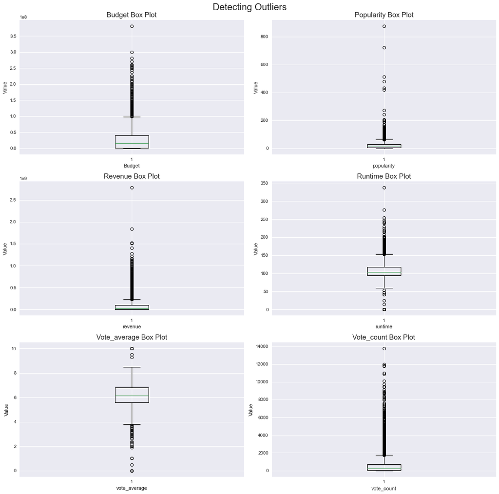

```python
plt.style.use("seaborn")
fig, axs = plt.subplots(3,2,figsize=(15, 15))
fig.suptitle('Detecting Outliers', fontsize=20,)

axs[0,0].boxplot(df["budget"])
axs[0,0].set(
    axisbelow=True,  # Hide the grid behind plot objects
    xlabel='Budget',
    ylabel='Value'
)

axs[0,0].set_title("Budget Box Plot", fontsize=15)


axs[0,1].boxplot(df["popularity"])
axs[0,1].set(
    axisbelow=True,  # Hide the grid behind plot objects
    xlabel='popularity',
    ylabel='Value'
)

axs[0,1].set_title("Popularity Box Plot", fontsize=15)


axs[1,0].boxplot(df["revenue"])
axs[1,0].set(
    axisbelow=True,  # Hide the grid behind plot objects
    xlabel='revenue',
    ylabel='Value'
)
axs[1,0].set_title("Revenue Box Plot", fontsize=15)


axs[1,1].boxplot(df["runtime"])
axs[1,1].set(
    axisbelow=True,  # Hide the grid behind plot objects
    xlabel='runtime',
    ylabel='Value'
)
axs[1,1].set_title("Runtime Box Plot", fontsize=15)




axs[2,0].boxplot(df["vote_average"])
axs[2,0].set(
    axisbelow=True,  # Hide the grid behind plot objects
    xlabel='vote_average',
    ylabel='Value'
)
axs[2,0].set_title("Vote_average Box Plot", fontsize=15)


axs[2,1].boxplot(df["vote_count"])
axs[2,1].set(
    axisbelow=True,  # Hide the grid behind plot objects
    xlabel='vote_count',
    ylabel='Value'
)
axs[2,1].set_title("Vote_count Box Plot", fontsize=15)


plt.tight_layout()
```

```python
#df["year"]=df["release_date"].dt.year
df.head()
```

|  | budget | genres | homepage | id | keywords | original_language | original_title | overview | popularity | production_companies | production_countries | release_date | revenue | runtime | spoken_languages | status | tagline | title | vote_average | vote_count |
| --- | --- | --- | --- | --- | --- | --- | --- | --- | --- | --- | --- | --- | --- | --- | --- | --- | --- | --- | --- | --- |
| 0 | 237000000 | [{'id': 28, 'name': 'Action'}, {'id': 12, 'nam... | http://www.avatarmovie.com/ | 19995 | [{'id': 1463, 'name': 'culture clash'}, {'id':... | en | Avatar | In the 22nd century, a paraplegic Marine is di... | 150.437577 | [{'name': 'Ingenious Film Partners', 'id': 289... | [{'iso_3166_1': 'US', 'name': 'United States o... | 2009-12-10 | 2787965087 | 162.0 | [{'iso_639_1': 'en', 'name': 'English'}, {'iso... | Released | Enter the World of Pandora. | Avatar | 7.2 | 11800 |
| 1 | 300000000 | [{'id': 12, 'name': 'Adventure'}, {'id': 14, '... | http://disney.go.com/disneypictures/pirates/ | 285 | [{'id': 270, 'name': 'ocean'}, {'id': 726, 'na... | en | Pirates of the Caribbean: At World's End | Captain Barbossa, long believed to be dead, ha... | 139.082615 | [{'name': 'Walt Disney Pictures', 'id': 2}, {'... | [{'iso_3166_1': 'US', 'name': 'United States o... | 2007-05-19 | 961000000 | 169.0 | [{'iso_639_1': 'en', 'name': 'English'}] | Released | At the end of the world, the adventure begins. | Pirates of the Caribbean: At World's End | 6.9 | 4500 |
| 2 | 245000000 | [{'id': 28, 'name': 'Action'}, {'id': 12, 'nam... | http://www.sonypictures.com/movies/spectre/ | 206647 | [{'id': 470, 'name': 'spy'}, {'id': 818, 'name... | en | Spectre | A cryptic message from Bond’s past sends him o... | 107.376788 | [{'name': 'Columbia Pictures', 'id': 5}, {'nam... | [{'iso_3166_1': 'GB', 'name': 'United Kingdom'... | 2015-10-26 | 880674609 | 148.0 | [{'iso_639_1': 'fr', 'name': 'Français'}, {'is... | Released | A Plan No One Escapes | Spectre | 6.3 | 4466 |
| 3 | 250000000 | [{'id': 28, 'name': 'Action'}, {'id': 80, 'nam... | http://www.thedarkknightrises.com/ | 49026 | [{'id': 849, 'name': 'dc comics'}, {'id': 853,... | en | The Dark Knight Rises | Following the death of District Attorney Harve... | 112.312950 | [{'name': 'Legendary Pictures', 'id': 923}, {'... | [{'iso_3166_1': 'US', 'name': 'United States o... | 2012-07-16 | 1084939099 | 165.0 | [{'iso_639_1': 'en', 'name': 'English'}] | Released | The Legend Ends | The Dark Knight Rises | 7.6 | 9106 |
| 4 | 260000000 | [{'id': 28, 'name': 'Action'}, {'id': 12, 'nam... | http://movies.disney.com/john-carter | 49529 | [{'id': 818, 'name': 'based on novel'}, {'id':... | en | John Carter | John Carter is a war-weary, former military ca... | 43.926995 | [{'name': 'Walt Disney Pictures', 'id': 2}] | [{'iso_3166_1': 'US', 'name': 'United States o... | 2012-03-07 | 284139100 | 132.0 | [{'iso_639_1': 'en', 'name': 'English'}] | Released | Lost in our world, found in another. | John Carter | 6.1 | 2124 |

```python
### Calculate the mean rate for [1999, 1980, 2004, 2017] the movies grouped by years ###
import numpy as np

df["year"] = df["release_date"].dt.year
grouped_df = df.groupby(["year"]).mean().reset_index()

print("The Average Rate for 2009 is:",np.round(
    grouped_df[grouped_df["year"]==2009]["vote_average"].values[0],6))

print("The Average Rate for 1999 is:",np.round(
    grouped_df[grouped_df["year"]==1999]["vote_average"].values[0],6))

print("The Average Rate for 1980 is:",np.round(
    grouped_df[grouped_df["year"]==1980]["vote_average"].values[0],6))

print("The Average Rate for 2004 is:",np.round(
    grouped_df[grouped_df["year"]==2004]["vote_average"].values[0],6))

print("The Average Rate for 2017 is:",np.round(
    grouped_df[grouped_df["year"]==2017]["vote_average"].values[0],6))
### Ex: Average Movies Rate at 2009 is 6.065587 ###
```

```
The Average Rate for 2009 is: 6.065587
The Average Rate for 1999 is: 6.110526
The Average Rate for 1980 is: 6.609091
The Average Rate for 2004 is: 6.104412
The Average Rate for 2017 is: 7.4
```

```python
df.columns
```

```
Index(['budget', 'genres', 'homepage', 'id', 'keywords', 'original_language',
       'original_title', 'overview', 'popularity', 'production_companies',
       'production_countries', 'release_date', 'revenue', 'runtime',
       'spoken_languages', 'status', 'tagline', 'title', 'vote_average',
       'vote_count', 'year'],
      dtype='object')
```

```python
### Rearange the dataframe based on revenue - budget values ###
column_names=['budget','revenue', 'genres', 'homepage', 'id', 'keywords', 'original_language',
       'original_title', 'overview', 'popularity', 'production_companies',
       'production_countries', 'release_date', 'runtime',
       'spoken_languages', 'status', 'tagline', 'title', 'vote_average',
       'vote_count', 'year']
#df.sort_values(["budget"],ascending=False).reindex(columns=column_names)
#df.sort_values(["revenue"],ascending=False).reindex(columns=column_names)
df.sort_values(["revenue","budget"],ascending=False).reindex(columns=column_names)
```

|  | budget | revenue | genres | homepage | id | keywords | original_language | original_title | overview | popularity | ... | production_countries | release_date | runtime | spoken_languages | status | tagline | title | vote_average | vote_count | year |
| --- | --- | --- | --- | --- | --- | --- | --- | --- | --- | --- | --- | --- | --- | --- | --- | --- | --- | --- | --- | --- | --- |
| 0 | 237000000 | 2787965087 | [{'id': 28, 'name': 'Action'}, {'id': 12, 'nam... | http://www.avatarmovie.com/ | 19995 | [{'id': 1463, 'name': 'culture clash'}, {'id':... | en | Avatar | In the 22nd century, a paraplegic Marine is di... | 150.437577 | ... | [{'iso_3166_1': 'US', 'name': 'United States o... | 2009-12-10 | 162.0 | [{'iso_639_1': 'en', 'name': 'English'}, {'iso... | Released | Enter the World of Pandora. | Avatar | 7.2 | 11800 | 2009.0 |
| 25 | 200000000 | 1845034188 | [{'id': 18, 'name': 'Drama'}, {'id': 10749, 'n... | http://www.titanicmovie.com | 597 | [{'id': 2580, 'name': 'shipwreck'}, {'id': 298... | en | Titanic | 84 years later, a 101-year-old woman named Ros... | 100.025899 | ... | [{'iso_3166_1': 'US', 'name': 'United States o... | 1997-11-18 | 194.0 | [{'iso_639_1': 'en', 'name': 'English'}, {'iso... | Released | Nothing on Earth could come between them. | Titanic | 7.5 | 7562 | 1997.0 |
| 16 | 220000000 | 1519557910 | [{'id': 878, 'name': 'Science Fiction'}, {'id'... | http://marvel.com/avengers_movie/ | 24428 | [{'id': 242, 'name': 'new york'}, {'id': 5539,... | en | The Avengers | When an unexpected enemy emerges and threatens... | 144.448633 | ... | [{'iso_3166_1': 'US', 'name': 'United States o... | 2012-04-25 | 143.0 | [{'iso_639_1': 'en', 'name': 'English'}] | Released | Some assembly required. | The Avengers | 7.4 | 11776 | 2012.0 |
| 28 | 150000000 | 1513528810 | [{'id': 28, 'name': 'Action'}, {'id': 12, 'nam... | http://www.jurassicworld.com/ | 135397 | [{'id': 1299, 'name': 'monster'}, {'id': 1718,... | en | Jurassic World | Twenty-two years after the events of Jurassic ... | 418.708552 | ... | [{'iso_3166_1': 'US', 'name': 'United States o... | 2015-06-09 | 124.0 | [{'iso_639_1': 'en', 'name': 'English'}] | Released | The park is open. | Jurassic World | 6.5 | 8662 | 2015.0 |
| 44 | 190000000 | 1506249360 | [{'id': 28, 'name': 'Action'}] | http://www.furious7.com/ | 168259 | [{'id': 830, 'name': 'car race'}, {'id': 3428,... | en | Furious 7 | Deckard Shaw seeks revenge against Dominic Tor... | 102.322217 | ... | [{'iso_3166_1': 'JP', 'name': 'Japan'}, {'iso_... | 2015-04-01 | 137.0 | [{'iso_639_1': 'en', 'name': 'English'}] | Released | Vengeance Hits Home | Furious 7 | 7.3 | 4176 | 2015.0 |
| ... | ... | ... | ... | ... | ... | ... | ... | ... | ... | ... | ... | ... | ... | ... | ... | ... | ... | ... | ... | ... | ... |
| 4795 | 0 | 0 | [{'id': 18, 'name': 'Drama'}] | <NA> | 124606 | [{'id': 10726, 'name': 'gang'}, {'id': 33928, ... | en | Bang | A young woman in L.A. is having a bad day: she... | 0.918116 | ... | [{'iso_3166_1': 'US', 'name': 'United States o... | 1995-09-09 | 98.0 | [{'iso_639_1': 'en', 'name': 'English'}] | Released | Sometimes you've got to break the rules | Bang | 6.0 | 1 | 1995.0 |
| 4797 | 0 | 0 | [{'id': 10769, 'name': 'Foreign'}, {'id': 53, ... | <NA> | 67238 | [] | en | Cavite | Adam, a security guard, travels from Californi... | 0.022173 | ... | [] | 2005-03-12 | 80.0 | [] | Released | <NA> | Cavite | 7.5 | 2 | 2005.0 |
| 4800 | 0 | 0 | [{'id': 35, 'name': 'Comedy'}, {'id': 18, 'nam... | http://www.hallmarkchannel.com/signedsealeddel... | 231617 | [{'id': 248, 'name': 'date'}, {'id': 699, 'nam... | en | Signed, Sealed, Delivered | "Signed, Sealed, Delivered" introduces a dedic... | 1.444476 | ... | [{'iso_3166_1': 'US', 'name': 'United States o... | 2013-10-13 | 120.0 | [{'iso_639_1': 'en', 'name': 'English'}] | Released | <NA> | Signed, Sealed, Delivered | 7.0 | 6 | 2013.0 |
| 4801 | 0 | 0 | [] | http://shanghaicalling.com/ | 126186 | [] | en | Shanghai Calling | When ambitious New York attorney Sam is sent t... | 0.857008 | ... | [{'iso_3166_1': 'US', 'name': 'United States o... | 2012-05-03 | 98.0 | [{'iso_639_1': 'en', 'name': 'English'}] | Released | A New Yorker in Shanghai | Shanghai Calling | 5.7 | 7 | 2012.0 |
| 4802 | 0 | 0 | [{'id': 99, 'name': 'Documentary'}] | <NA> | 25975 | [{'id': 1523, 'name': 'obsession'}, {'id': 224... | en | My Date with Drew | Ever since the second grade when he first saw ... | 1.929883 | ... | [{'iso_3166_1': 'US', 'name': 'United States o... | 2005-08-05 | 90.0 | [{'iso_639_1': 'en', 'name': 'English'}] | Released | <NA> | My Date with Drew | 6.3 | 16 | 2005.0 |

4803 rows × 21 columns

```python
### Allocate the year with the largest movies released in ['Action', 'Romance'] ###
years = []

for i,row in df.iterrows():
    lst = []

    for i in range(len(row["genres"])):
        lst.append(row["genres"][i]["name"])

    if ("Action" in lst) and ("Romance" in lst):
        years.append(row["year"])

print(years)
print("The Largest year with Movie releases Action and Romance is: ",max(years,key=years.count))
```

```
[2010.0, 2014.0, 2015.0, 2004.0, 2010.0, 1997.0, 1998.0, 1998.0, 2014.0, 2010.0, 2001.0, 1995.0, 2012.0, 2000.0, 2000.0, 2006.0, 2013.0, 2013.0, 1995.0, 2001.0, 1992.0, 2001.0, 2007.0, 2004.0, 2005.0, 2005.0, 1992.0, 2011.0, 2001.0, 2012.0, 1990.0, 2002.0, 1981.0, 1986.0, 2007.0, 1986.0, 2000.0, 200…
The Largest year with Movie releases Action and Romance is:  2000.0
```

```python
### Find the movies with top 5 revenue - budget value ###
### Rearange the dataframe based on revenue - budget values ###
column_names=['budget','revenue', 'genres', 'homepage', 'id', 'keywords', 'original_language',
       'original_title', 'overview', 'popularity', 'production_companies',
       'production_countries', 'release_date', 'runtime',
       'spoken_languages', 'status', 'tagline', 'title', 'vote_average',
       'vote_count', 'year']

print("The Movies with top 5 Revenue are:")

top_rev_movies = df.sort_values(
    ["budget"],ascending=False).reindex(columns=column_names)\
        [["title","budget"]].head(5).reset_index(drop=True)

print(top_rev_movies)

print("#############################################################")

print("The Movies with top 5 budget are:")

top_budget_movies = df.sort_values(
    ["revenue"],ascending=False).reindex(columns=column_names)\
        [["title","budget"]].head(5).reset_index(drop=True)

print(top_budget_movies)
```

[output not shown]

```python
### Find the year with the highest number of movies release ###
column_names = ['budget','revenue', 'genres', 'homepage', 'id', 'keywords',
    'original_language', 'original_title', 'overview', 'popularity', 'production_companies',
       'production_countries', 'release_date', 'runtime','spoken_languages',
                'status', 'tagline', 'title', 'vote_average', 'vote_count', 'year']

df.groupby(["year"]).count().reset_index()\
    [["year","release_date"]].sort_values(
        by=["release_date"],ascending=False)[0:1].\
            rename(columns={'release_date': 'Count_Movies'})
```

|  | year | Count_Movies |
| --- | --- | --- |
| 81 | 2009.0 | 247 |

```python
### Find the top 2 countries with the highest production movies number ###
lst = []
dict1 = {}

for i, row in df.iterrows():

    for j in range(len(row["production_countries"])):

        if row["production_countries"][j]["name"] not in lst:
            dict1[row["production_countries"][j]["name"]] = 1
            lst.append(row["production_countries"][j]["name"])

        else:
            val=dict1[row["production_countries"][j]["name"]]
            dict1[row["production_countries"][j]["name"]] = val+1

sorted_dict = {k: v for k, v in sorted(dict1.items(),
                                       key=lambda item: item[1], reverse=True)}

print("The top 2 countries with the highest production movies number ")

print(list(sorted_dict.items())[0])

print(list(sorted_dict.items())[1])
```

```
The top 2 countries with the highest production movies number
('United States of America', 3956)
('United Kingdom', 636)
```

```python
### Find the top 1 company with the highest production movies number ###
lst = []
dict1 = {}

for i, row in df.iterrows():

    for j in range(len(row["production_companies"])):

        if row["production_companies"][j]["name"] not in lst:
            dict1[row["production_companies"][j]["name"]] = 1
            lst.append(row["production_companies"][j]["name"])

        else:
            val=dict1[row["production_companies"][j]["name"]]
            dict1[row["production_companies"][j]["name"]] = val+1

sorted_dict = {k: v for k, v in sorted(dict1.items(),
                                       key=lambda item: item[1], reverse=True)}

print("The top 1 company with the highest production movies number ")

print(list(sorted_dict.items())[0])
```

```
The top 1 company with the highest production movies number
('Warner Bros.', 319)
```

```
The correlation coefficient between runtime and vote average is: 0.3741322210354357
It is appeared,from plot and correlation coefficient, that it is weak or no correlation
```

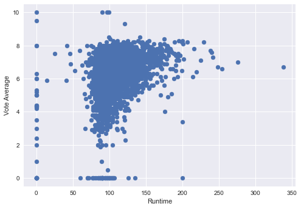

```python
### Is there any relation between the runtime and average vote value ### **
plt.scatter(df["runtime"], df["vote_average"])
plt.xlabel("Runtime")
plt.ylabel("Vote Average")

print("The correlation coefficient between runtime and vote average is:",
      df['runtime'].corr(df['vote_average']))

print("It is appeared,from plot and correlation coefficient,\
            that it is weak or no correlation")
```

```python
### Find the top 5 movies with the highest rate, and find if there anything common between them. ###
print(df.sort_values(by=["vote_average"],ascending=False)\
      [0:5][["title","vote_average"]])

print()
print("The commom is: 1- Original Language is EN")
print("2-Vote count is low max 2")
print("3-There is no Revenue in most of them")
print("4-most of them Comedy or Drama")
```

```
                      title  vote_average
3519       Stiff Upper Lips          10.0
4247  Me You and Five Bucks          10.0
4045  Dancer, Texas Pop. 81          10.0
4662         Little Big Top          10.0
3992              Sardaarji           9.5

The commom is: 1- Original Language is EN
2-Vote count is low max 2
3-There is no Revenue in most of them
4-most of them Comedy or Drama
```

```python
### Find the most unsuccessful movie along time in terms of revenue - budget ###
pd.set_option('display.max_columns', 500)
df["Profit"]=df["revenue"]-df["budget"]

print("The most unsuccessful movie along time:")

df.sort_values(by=["Profit"],ascending=True)\
    [["title", "budget", "revenue", "Profit"]][0:10]
```

```
The most unsuccessful movie along time:
```

|  | title | budget | revenue | Profit |
| --- | --- | --- | --- | --- |
| 13 | The Lone Ranger | 255000000 | 89289910 | -165710090 |
| 135 | The Wolfman | 150000000 | 0 | -150000000 |
| 338 | The Alamo | 145000000 | 25819961 | -119180039 |
| 141 | Mars Needs Moms | 150000000 | 38992758 | -111007242 |
| 1652 | Dragonball Evolution | 100000000 | 0 | -100000000 |
| 208 | The 13th Warrior | 160000000 | 61698899 | -98301101 |
| 311 | The Adventures of Pluto Nash | 100000000 | 7103973 | -92896027 |
| 2638 | Metropolis | 92620000 | 650422 | -91969578 |
| 376 | Volcano | 90000000 | 0 | -90000000 |
| 467 | Mighty Joe Young | 90000000 | 0 | -90000000 |

```python
### Rearange the dataframe based on vote_average column values ###
df.sort_values(by=["vote_average"], ascending=False)
```

|  | budget | genres | homepage | id | keywords | original_language | original_title | overview | popularity | production_companies | production_countries | release_date | revenue | runtime | spoken_languages | status | tagline | title | vote_average | vote_count | year | Profit |
| --- | --- | --- | --- | --- | --- | --- | --- | --- | --- | --- | --- | --- | --- | --- | --- | --- | --- | --- | --- | --- | --- | --- |
| 3519 | 0 | [{'id': 35, 'name': 'Comedy'}] | <NA> | 89861 | [{'id': 131, 'name': 'italy'}, {'id': 8250, 'n... | en | Stiff Upper Lips | Stiff Upper Lips is a broad parody of British ... | 0.356495 | [] | [{'iso_3166_1': 'GB', 'name': 'United Kingdom'... | 1998-06-12 | 0 | 99.0 | [{'iso_639_1': 'en', 'name': 'English'}] | Released | <NA> | Stiff Upper Lips | 10.0 | 1 | 1998.0 | 0 |
| 4247 | 1 | [{'id': 10749, 'name': 'Romance'}, {'id': 35, ... | <NA> | 361505 | [] | en | Me You and Five Bucks | A womanizing yet lovable loser, Charlie, a wai... | 0.094105 | [] | [] | 2015-07-07 | 0 | 90.0 | [] | Released | A story about second, second chances | Me You and Five Bucks | 10.0 | 2 | 2015.0 | -1 |
| 4045 | 0 | [{'id': 35, 'name': 'Comedy'}, {'id': 18, 'nam... | <NA> | 78373 | [{'id': 1415, 'name': 'small town'}, {'id': 15... | en | Dancer, Texas Pop. 81 | Four guys, best friends, have grown up togethe... | 0.376662 | [{'name': 'HSX Films', 'id': 4714}, {'name': '... | [{'iso_3166_1': 'US', 'name': 'United States o... | 1998-05-01 | 565592 | 97.0 | [{'iso_639_1': 'en', 'name': 'English'}] | Released | in the middle of nowhere they had everything | Dancer, Texas Pop. 81 | 10.0 | 1 | 1998.0 | 565592 |
| 4662 | 0 | [{'id': 35, 'name': 'Comedy'}] | <NA> | 40963 | [{'id': 10183, 'name': 'independent film'}] | en | Little Big Top | An aging out of work clown returns to his smal... | 0.092100 | [{'name': 'Fly High Films', 'id': 24248}] | [{'iso_3166_1': 'US', 'name': 'United States o... | 2006-01-01 | 0 | 0.0 | [{'iso_639_1': 'en', 'name': 'English'}] | Rumored | <NA> | Little Big Top | 10.0 | 1 | 2006.0 | 0 |
| 3992 | 0 | [] | <NA> | 346081 | [] | en | Sardaarji | A ghost hunter uses bottles to capture trouble... | 0.296981 | [] | [{'iso_3166_1': 'IN', 'name': 'India'}] | 2015-06-26 | 0 | 0.0 | [] | Released | <NA> | Sardaarji | 9.5 | 2 | 2015.0 | 0 |
| ... | ... | ... | ... | ... | ... | ... | ... | ... | ... | ... | ... | ... | ... | ... | ... | ... | ... | ... | ... | ... | ... | ... |
| 3960 | 0 | [{'id': 35, 'name': 'Comedy'}, {'id': 10751, '... | https://www.facebook.com/pages/The-Deported/46... | 170480 | [] | en | The Deported | An Italian-American actor is deported to Mexic... | 0.194848 | [] | [] | 2010-06-15 | 0 | 90.0 | [{'iso_639_1': 'en', 'name': 'English'}] | Released | <NA> | The Deported | 0.0 | 0 | 2010.0 | 0 |
| 4684 | 0 | [{'id': 27, 'name': 'Horror'}] | <NA> | 402515 | [{'id': 321, 'name': 'terror'}, {'id': 8087, '... | pt | Solitude | After finding an old storage locker filled wit... | 0.018716 | [{'name': 'Gravitas Ventures', 'id': 44632}] | [{'iso_3166_1': 'US', 'name': 'United States o... | 2014-10-21 | 0 | 89.0 | [{'iso_639_1': 'en', 'name': 'English'}] | Released | <NA> | American Beast | 0.0 | 0 | 2014.0 | 0 |
| 3967 | 3 | [{'id': 18, 'name': 'Drama'}, {'id': 35, 'name... | <NA> | 79587 | [] | en | Four Single Fathers | A comedy/drama about four Italian single fathe... | 0.008263 | [{'name': 'Indiana Production Company', 'id': ... | [{'iso_3166_1': 'US', 'name': 'United States o... | 2009-01-15 | 0 | 100.0 | [{'iso_639_1': 'it', 'name': 'Italiano'}, {'is... | Released | Comedy | Four Single Fathers | 0.0 | 0 | 2009.0 | -3 |
| 4486 | 700000 | [{'id': 18, 'name': 'Drama'}] | http://naturallynative.com/home.html | 302579 | [{'id': 10322, 'name': 'native american'}, {'i... | en | Naturally Native | Naturally Native follows the lives, loves, pai... | 0.578798 | [{'name': 'Red-horse Native', 'id': 38147}] | [{'iso_3166_1': 'US', 'name': 'United States o... | 1999-10-08 | 10508 | 107.0 | [{'iso_639_1': 'en', 'name': 'English'}] | Released | Sometimes When You're Going Home, It's Importa... | Naturally Native | 0.0 | 0 | 1999.0 | -689492 |
| 4458 | 0 | [] | <NA> | 279759 | [] | en | Harrison Montgomery | Film from Daniel Davila | 0.006943 | [] | [] | 2008-01-01 | 0 | 0.0 | [] | Released | <NA> | Harrison Montgomery | 0.0 | 0 | 2008.0 | 0 |

4803 rows × 22 columns